# Lab2

```python
import numpy as np
import matplotlib
import matplotlib.pyplot as plt
import scipy
import pandas as pd
from scipy import stats

#this sets the size of the plot to something useful
plt.rcParams["figure.figsize"] = (10,6.5)
plt.rcParams["xtick.labelsize"] = 10
plt.rcParams["ytick.labelsize"] = 10
```

## Lab #2: Probability, Distributions, and Statistical Questions

### Problem 1

In lecture and homework we explored how the convolution can be used to calculate the probability of a sum or average. For this problem we are going to imagine that we are looking for gamma-ray sources (e.g. with the Fermi telescope). In this kind of telescope there is a background of cosmic-rays (electrons and protons, mostly) that provides a discrete noise term across the sky that precisely follows a Poisson distribution. To detect a gamma-ray source, you need to ask what is the probability that the cosmic-ray background would have given you a measurement as signal-like or more than the signal that you received.

To set up the problem, assume in 1 day the average cosmic-ray background is some number X (pick someting btwn 0.5 and 10, with different values for you and your lab partner); and the average number of gamma-rays emitted by your hypothetical source is Y (pick something larger than X).

#### A) Show how the probability distribution of the background changes as you integrate (sum) for more days.

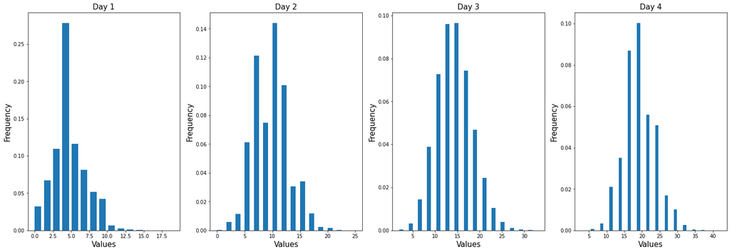

```python
# average cosmic-ray background:
X = 5

fig, ax = plt.subplots(nrows=1, ncols=4, figsize=(25,8))
dist_sum = stats.poisson.rvs(mu = X, size = 100000)
for i in range(0, 4):
    ax[i].hist(dist_sum, width=0.9, bins=15, density=True)
    ax[i].set_title("Day "+str(i+1), fontsize=15)
    ax[i].set_xlabel("Values", fontsize=15)
    ax[i].set_ylabel("Frequency", fontsize=15)
    dist_sum = dist_sum + stats.poisson.rvs(mu = X, size = 100000)
```

As we sum for more days, as we can see from these normalized Poisson distributions, the distribution gradually shifts to the right since the magnitude of the values keeps increasing as we add the distribution to each other.

#### B) Show that after 5 days, the summed probability distribution is still a Poisson distribution. Explain why this makes sense from a mathematical and conceptual point of view.

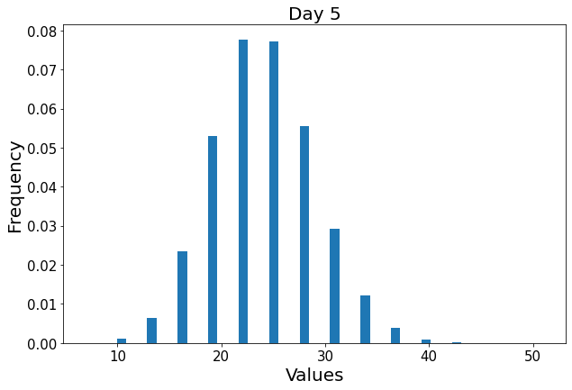

```python
fig, ax = plt.subplots(1, 1)
ax.hist(dist_sum, width=0.9, bins=15, density=True)
ax.set_title("Day 5", fontsize=20)
ax.set_xlabel("Values", fontsize=20)
ax.set_ylabel("Frequency", fontsize=20)
ax.tick_params(axis='both', which='major', labelsize=15)
```

The distribution for day 5, plotted above, is still a Poisson distribution. Mathematically, since the values that were added together are integers (discrete) the sum of integers will still be integers, so this distribution is still discrete. Conceptually, our background data is cosmic rays, which are discrete - it makes no sense to talk about half a cosmic ray, so the sum of cosmic ray data must also be discrete.

#### C) Show how the probability distribution evolves as you average days. Calculate for many different ranges of days, and explore the shape of the distribution as the number of days becomes larger. Discuss this in relation to both B) and the central limit theorem.

```
Upper bound of x: 20
```

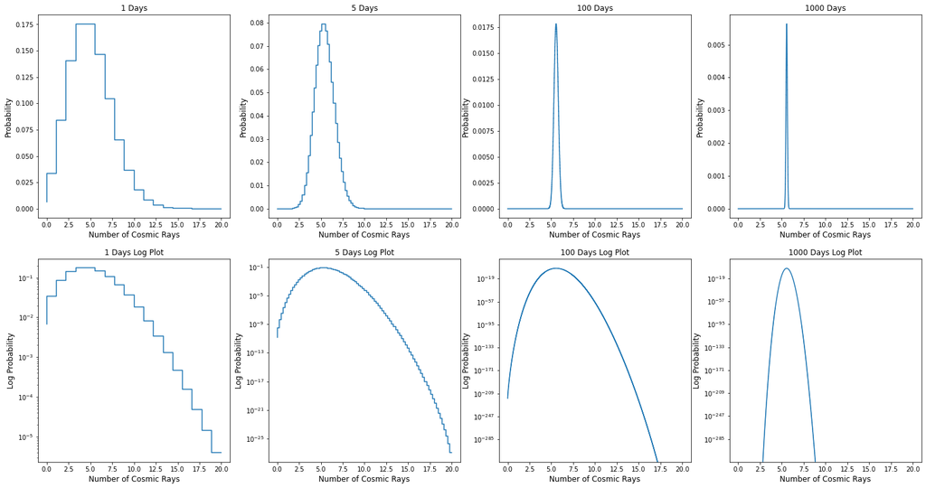

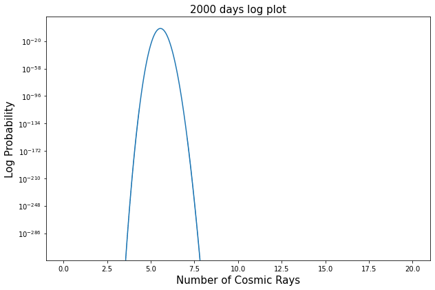

```python
fig, ax = plt.subplots(2, 4, figsize=(25, 13))
mu = 5
x = np.arange(stats.poisson.ppf(0.000001, mu), stats.poisson.ppf(0.999999, mu))
x_upper = len(x) + 1
print("Upper bound of x: " + str(x_upper))
poisson = stats.poisson.pmf(x, mu)
convolves = poisson
plot_count = 0
for i in range(1, 2000):
    if (i==1) | (i==5) | (i==100) | (i==1000):
        x = np.linspace(0, x_upper, len(convolves))
        ax[0][plot_count].step(x, convolves)
        ax[0][plot_count].set_title(str(i) + " Days", fontsize=12)
        ax[0][plot_count].set_xlabel("Number of Cosmic Rays", fontsize=12)
        ax[0][plot_count].set_ylabel("Probability", fontsize=12)
        ax[1][plot_count].step(x, convolves)
        ax[1][plot_count].set_title(str(i) + " Days Log Plot", fontsize=12)
        ax[1][plot_count].set_xlabel("Number of Cosmic Rays", fontsize=12)
        ax[1][plot_count].set_ylabel("Log Probability", fontsize=12)
        ax[1][plot_count].set_yscale("log")
        plot_count = plot_count + 1
    convolves = np.convolve(convolves, poisson)

fig, ax = plt.subplots(1, 1)
x = np.linspace(0, x_upper, len(convolves))
ax.step(x, convolves)
plt.title("2000 days log plot", fontsize = 15)
plt.ylabel("Log Probability", fontsize = 15)
plt.xlabel("Number of Cosmic Rays", fontsize = 15)
plt.yscale("log")
```

As shown in part B, and by the log plot for the average over 5 days, the average probability distribution still looks discrete (Poisson) and highly skewed on the log plot. However, as we average over more days the log plot looks more like an upside-down parabola, or looks more Guassian. By 2000 days, the log plot of the probability distribution for the average of cosmic rays (that follow a Poisson distribution if we're only looking at one day) looks quite Gaussian, which is consistent with the Central Limit Theorem which states that the sum or average of many independent samples of a random variable, which may not be normal, is approximately a normal random variable.

#### D) Pick some number of days N, and assume you saw Y*N gamma rays from your source. Calculate the 'sigma' of your observation. [In reality the number of gamma-rays seen from a source will also fluctuate, but we're going to ignore that complication for a couple of labs.]

```python
# average number of gamma-rays emitted by hypothetical source per day:
Y = 6
# Choose N = 2000 days
# convolves: the list of probabilities from the average of 2000 days from part C
# x_upper = 20: dependent on range of poisson distribution used for convolution
prob = 0
x = np.linspace(0, x_upper, len(convolves))
for i in range(len(convolves)):
    if x[i] > 6: # sum probability for all probabilities for x > 6
        prob = prob + convolves[i]
print("Assuming there is no signal, we expect the background to have the pdf of 2000 convolved Poisson distributions with expected value 5.")
print("The probability of the background producing a signal greater than 6 gamma rays per day on average:")
print("Probability: " + str(prob))
print("Associated sigma value: " + str(abs(stats.norm.ppf(prob))))
```

```
Assuming there is no signal, we expect the background to have the pdf of 2000 convolved Poisson distributions with expected value 5.
The probability of the background producing a signal greater than 6 gamma rays per day on average:
Probability: 1.3471788759584675e-15
Associated sigma value: 7.9043035275486515
```

### Problem 2

Pick a skewed continuous distribtuion, such as a Rayleigh, that describes your background over some observing interval.

#### A) Show how the distribution changes as you average over more observing intervals.

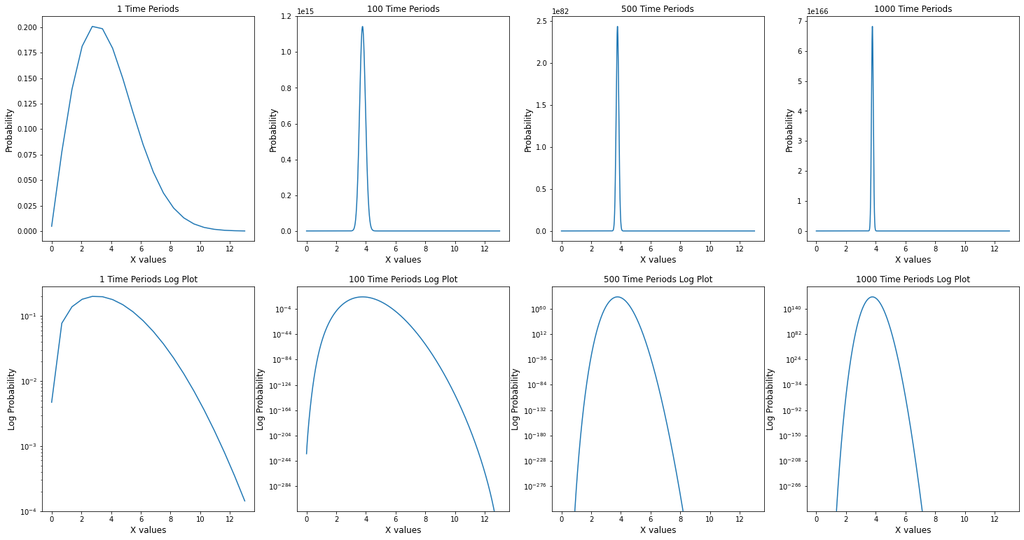

```python
fig, ax = plt.subplots(2, 4, figsize=(25, 13))
x = np.linspace(stats.rayleigh.ppf(0.0001, scale=3), stats.rayleigh.ppf(0.9999, scale=3), 20)
rayleigh = stats.rayleigh.pdf(x, scale=3)
convolves = rayleigh
plot_count = 0
for i in range(1, 1001):
    if (i==1) | (i==100) | (i==500) | (i==1000):
        x = np.linspace(0, 13, len(convolves))
        ax[0][plot_count].plot(x, convolves)
        ax[0][plot_count].set_title(str(i) + " Time Periods", fontsize=12)
        ax[0][plot_count].set_xlabel("X values", fontsize=12)
        ax[0][plot_count].set_ylabel("Probability", fontsize=12)
        ax[1][plot_count].plot(x, convolves)
        ax[1][plot_count].set_title(str(i) + " Time Periods Log Plot", fontsize=12)
        ax[1][plot_count].set_xlabel("X values", fontsize=12)
        ax[1][plot_count].set_ylabel("Log Probability", fontsize=12)
        ax[1][plot_count].set_yscale("log")
        plot_count = plot_count + 1
    convolves = np.convolve(convolves, rayleigh)
```

### Problem 3

The discovery of optical/infra-red counterparts of Neutron star mergers initially detected with gravity-waves is one of the great discoverys in the last few years (wikipedia, scientific paper), and has ushered in the age of "multi-messenger astrophysics." The science that can be done by matching a gravity-wave signal (directly measures the mass of the neutron stars and their distance) with the optical emisson (redshift, nuclear astrophysics of the resulting explosion) is staggering. Lots of science from how the heaviest elements are formed to constraints on Dark Energy.

We're going to explore one of the analysis questions that comes up when looking for the optical counterparts (a new optical source) of a gravity wave signal. For this problem let's assume that we are using an optical telescope with a thermal noise background from the CCD (dark current, particularly an issue with older CCDs and/or infra-red CCDs). After flat-fielding, the background appears as a zero-mean Gaussian with constant width over the image.

#### Version 1

You have an alert from LIGO that is also seen in with the X-ray/ultra-violet satellite SWIFT. SWIFT gives you a very precise location, so you take an image of that part of the sky. But because of SWIFT's accuracy, you know which pixel in your image to look for a counterpart in.

##### A)

From looking at all the other pixels in your image, you can measure the width of the background Gaussian distribution X (pick something). Assuming you see a signal of strength Y (pick a floating-point number; optical CCDs are not sensitive enough to count photons so the readings are floating point brightnesses, not integer photons). Calculate the significance of your detection. Can you claim a discovery (traditionally 5-sigma or more)?

```python
# Assume background has Gaussian distribution with mean zero and standard deviation 1.5
Y = 8.2
prob = stats.norm.cdf(-Y, scale=1.5)
sigma = abs(stats.norm.ppf(prob))
print("Probability: " + str(prob))
print("Associated sigma: " + str(sigma))
```

```
Probability: 2.2928862116085394e-08
Associated sigma: 5.466666666666665
```

If the value we choose is 8.2, and the background for the pixel has a Gaussian distribution with mean of zero and standard deviation of 1.5, we can claim a discovery since the value is associated with a sigma value greater than 5.

### Version 2

You have an alert from LIGO, but no associated detection from SWIFT. This could be because it is a black hole-black hole merger, a black hole-neutron star merger (neither seem to emit X-rays or UV light), or it could because SWIFT was indisposed at the time (wrong side of the earth in its orbit). Whatever the cause, you know what region of the sky to look in, but not which pixel.

#### B)

If you have to look for a signal in 10k pixels, what is the probability distribution of your background? (Clearly state the statistical question, then turn that into math using your background distribution from part 1 of this problem.)

If each pixel has the background of a Gaussian with mean zero and std dev 1.5, then we expect the background of 10k pixels to have the pdf of 10,000 convolved normal distributions. What is the probability of the background producing a signal as bright or brighter than 8.2?

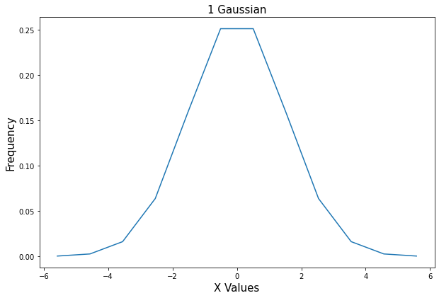

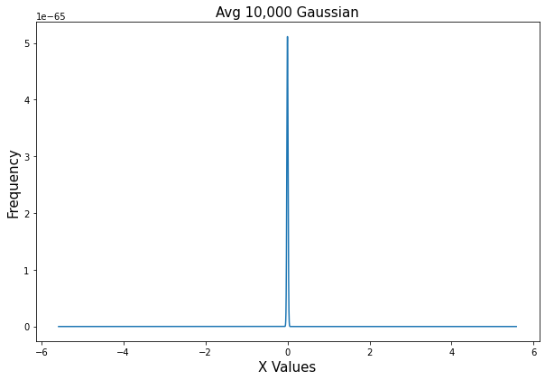

```python
fig, ax = plt.subplots(1, 1)
x = np.linspace(stats.norm.ppf(0.0001, scale=1.5), stats.norm.ppf(0.9999, scale=1.5), 12)
norm = stats.norm.pdf(x, scale=1.5)
ax.plot(x, norm)
plt.title("1 Gaussian", fontsize = 15)
plt.ylabel("Frequency", fontsize = 15)
plt.xlabel("X Values", fontsize = 15)
background = norm
for i in range(1, 10000):
    background = np.convolve(background, norm)

fig, ax = plt.subplots(1, 1)
x = np.linspace(x[0], x[len(x)-1], len(background))
ax.plot(x, background)
plt.title("Avg 10,000 Gaussian", fontsize = 15)
plt.ylabel("Frequency", fontsize = 15)
plt.xlabel("X Values", fontsize = 15)
```

#### C)

Taking your brightest candidate signal from the region (assume it has the same signal as in part 1), calculate the significance of your detection.

```python
value = 8.2/10000
prob = 0
for i in range(len(x)):
    if x[i] > value:
        prob = prob + background[i]
print(prob)
print("sigma: " + str(abs(stats.norm.ppf(prob))))
```

```
9.036095114216689e-63
sigma: 16.680819733967436
```

### Problem 4

The statistical issue we were exploring in the previous problem is called a trials factor (sometimes known as a look-elsewhere effect). This is an important effect, as if you search through a million locations, you would expect to se ~1 one in a million event. However, it is also often over estimated how big an impact this makes on the sensitivity of a search. So in this part of the lab we are going to invert the problem.

Let us again assume we have a Gaussian background (same parameters as Problem 3).

#### A)

Calculate the signal required for a 5-sigma detection in Version 1

```python
prob_5_sigma = stats.norm.cdf(-5)
value = abs(stats.norm.ppf(prob_5_sigma, scale=1.5))
print("prob 5 sigma: " + str(prob_5_sigma))
print("value: " + str(value))
```

```
prob 5 sigma: 2.866515718791933e-07
value: 7.500000000000002
```

#### B)

Calculate the signal required for a 5-sigma detection in Version 2

```python
cum_prob = 0
i = len(x) - 1
sum = 0
for i in background:
    sum = sum + i
threshold = sum * prob_5_sigma
tracking = 0
for i in range(len(x)-1, 0, -1):
    if tracking > threshold:
        break
    tracking = tracking + background[i]
x[i]*10000
```

```
748.5365908001196
```

```python
abs(stats.norm.ppf(prob_5_sigma, scale=np.std(background)))
```

```
1.244317061039522e-65
```

#### C)

Discuss how much brighter the signal must be for discoverey if you have a trials factor of 10k. Looking at your probability distributions, explain why the sensitivity penalty due to a trials factor is so low.

After doing convolution 10,000 times, the overall probability under the curve has shrunk substantially, so when we try to calculate for 5 sigma probability, the numbers that come back are very skewed, possibly due to rounding errors when the numbers we are dealing with get so small.

#### D)

If you changed the trials factor significantly (orders of magnitude), how large is the effect on your 5-sigma sensitivity threshold?